# R Notebook

# Experimental Design and Data Analysis: Assignment 4

This assignment consists of 4 exercises. Throughout this assignment tests should be performed using a level of 0.05. You will need to install the R-packages multcomp and lme4, which are not included in the standard distribution of R. To use the package either choose multcomp and lme4 in menu Packages or type library(multcomp) library(lme4) Installing is a one-time task, loading the package is necessary at every R session. ## EXERCISE 1

```r
bread = read.table("bread.txt", header=TRUE, quote="\"")
names(bread)[2] = "temperature"
```

If left alone bread will become moldy, rot or decay otherwise. To investigate the influence of temperature and humidity on this process, the time to decay was measured for 18 slices of white bread, which were placed in 3 different environments and humidified or not. The data are given in the file bread.txt, with the first column time to decay in hours, the second column the environment (cold, warm or intermediate temperature) and the third column the humidity. ###1. The 18 slices came from a single loaf, but were randomized to the 6 combinations of conditions. Present an R-code for this randomization process.

```r
# 18 slices, 6 combinations (3 env, 2 humid), 3 slices per combination
I=3; J=2; N=3;
rbind(rep(1:I,each=N*J), rep(1:J,N*I), sample(1:(N*I*J)))
```

```
     [,1] [,2] [,3] [,4] [,5] [,6] [,7] [,8] [,9] [,10] [,11] [,12] [,13] [,14] [,15] [,16] [,17] [,18]
[1,]    1    1    1    1    1    1    2    2    2     2     2     2     3     3     3     3     3     3
[2,]    1    2    1    2    1    2    1    2    1     2     1     2     1     2     1     2     1     2
[3,]   13    2   14    5    4   11   17    8   16     1    15    18    12     3     6     9    10     7
```

### 2. Make two boxplots of hours versus the two factors and two interaction plots (keeping the two factors fixed in turn).

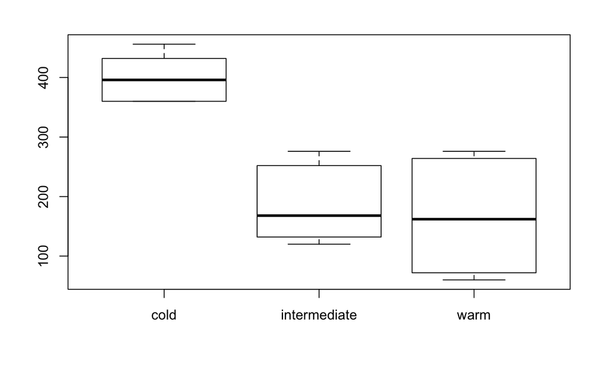

```r
boxplot(hours~temperature,data=bread)
```

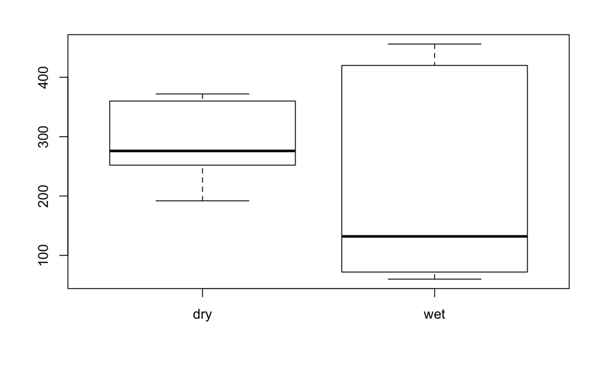

```r
boxplot(hours~humidity,data=bread)
```

### 3. Perform an analysis of variance to test for effect of the factors temperature, humidity, and their interaction. Describe the interaction effect in words.

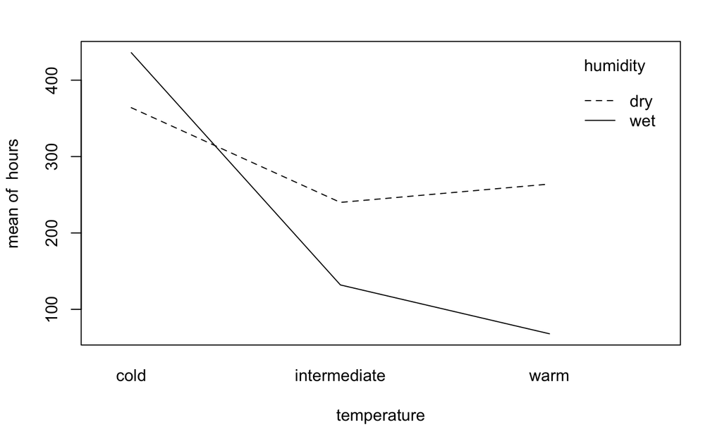

```r
attach(bread)
interaction.plot(temperature,humidity,hours)
```

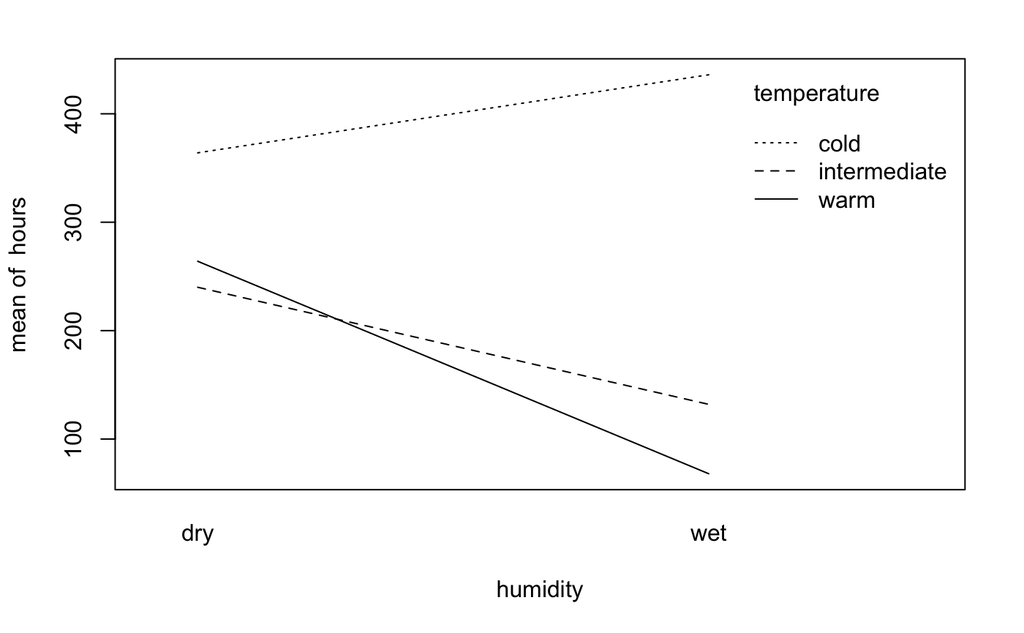

```r
interaction.plot(humidity,temperature,hours)
```

### 4. Which of the two factors has the greatest (numerical) influence on the decay? Is this a good question?

```r
bread$temperature=as.factor(bread$temperature)
bread$humidity=as.factor(bread$humidity)
breadaov=lm(hours~temperature*humidity,data=bread)
anova(breadaov)
```

[output not shown]

### 5. Check the model assumptions by using relevant diagnostic tools. Are there any outliers?

```r
## Exercise 1.6 ##
contrasts(bread$temperature)=contr.sum
contrasts(bread$humidity)=contr.sum
breadaov2=lm(hours~temperature*humidity,data=bread)
summary(breadaov2)
```

```
Call:
lm(formula = hours ~ temperature * humidity, data = bread)

Residuals:
   Min     1Q Median     3Q    Max
   -48     -7      0     11     36

Coefficients:
                       Estimate Std. Error t value Pr(>|t|)
(Intercept)             250.667      4.899  51.167 2.04e-15 ***
temperature1            149.333      6.928  21.554 5.81e-11 ***
temperature2            -64.667      6.928  -9.334 7.50e-07 ***
humidity1                38.667      4.899   7.893 4.32e-06 ***
temperature1:humidity1  -74.667      6.928 -10.777 1.59e-07 ***
temperature2:humidity1   15.333      6.928   2.213    0.047 *
---
Signif. codes:  0 ‘***’ 0.001 ‘**’ 0.01 ‘*’ 0.05 ‘.’ 0.1 ‘ ’ 1

Residual standard error: 20.78 on 12 degrees of freedom
Multiple R-squared:  0.9821,    Adjusted R-squared:  0.9747
F-statistic: 131.9 on 5 and 12 DF,  p-value: 4.676e-10
```

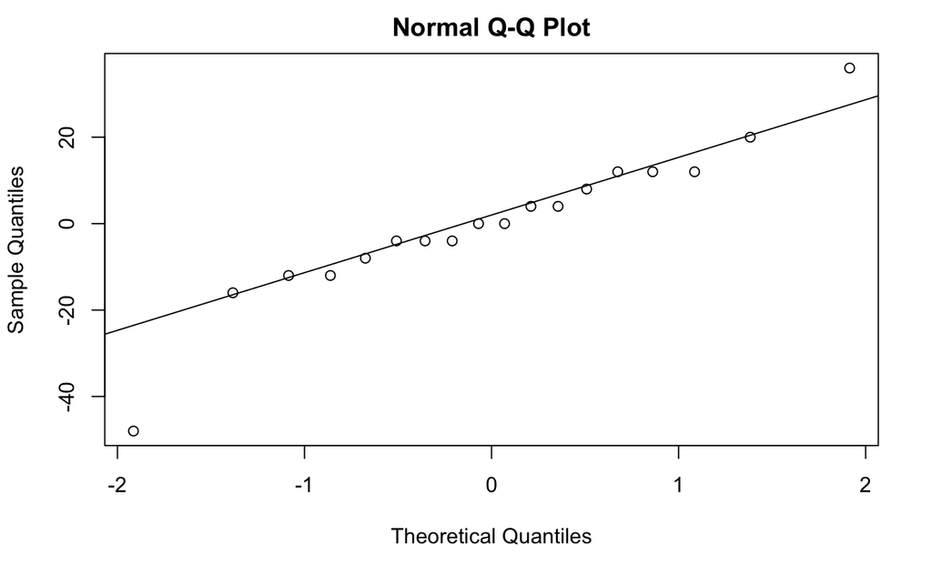

```r
## Exercise 1.7 ##
qqnorm(residuals(breadaov2))
qqline(residuals(breadaov2))
```

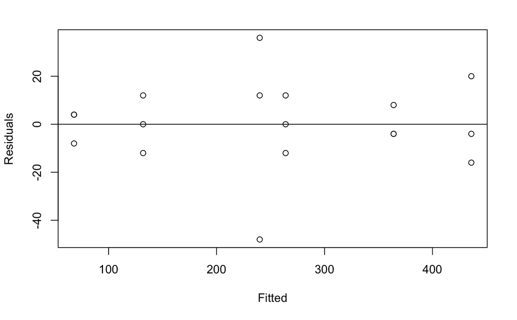

```r
## Exercise 1.8 ##
plot(fitted(breadaov2),residuals(breadaov2),xlab="Fitted",ylab="Residuals")
abline(h=0)
```

## EXERCISE 2

```r
search = read.table("search.txt", header=TRUE, quote="\"")
```

A researcher is interested in the time it takes a student to find a certain product on the internet using a search engine. There are three different types of interfaces with the search engine and especially the effect of these interfaces is of importance. There are five different types of students, indicating their level of computer handling (the lower the value of this indicator, the better the computer handling of the corresponding student). Fifteen students are selected; three from each group with a certain level of computer handling. ###1. Number the selected students 1 to 15 and show how the students could be randomized to the interfaces in a randomized block design, by using R. 1 The experiment was run according to a randomized block design, as described. The data is given in the file search.txt.

```r
I=3;B=5;N=1
for (i in 1:B) {print(sample(1:(N*I)))}
```

```
[1] 3 1 2
[1] 2 1 3
[1] 1 2 3
[1] 2 1 3
[1] 3 1 2
```

### 2. Make some graphical summaries of the data. Are any interactions between interface and skill apparent?

```r
attach(search)
par(mfrow=c(1,2))
xtabs(time~interface+skill,data=search)
```

```
         skill
interface    1    2    3    4    5
        1 16.1 14.5 17.6 21.1 21.5
        2 15.6 20.4 19.8 24.8 23.7
        3 20.5 21.2 23.9 22.2 25.3
```

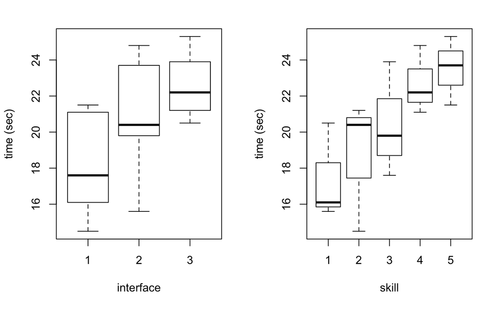

```r
boxplot(time~interface, xlab="interface", ylab="time (sec)")
boxplot(time~skill, xlab="skill", ylab="time (sec)")
```

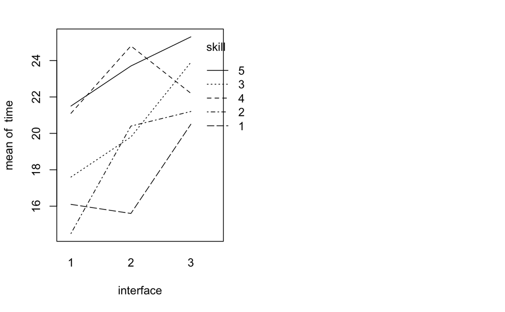

```r
interaction.plot(interface,skill,time)
interaction.plot(skill,interface,time)
```

[output not shown]

### 3. Test the null hypothesis that the search time is the same for all interfaces. (Beware that the levels of the factors are coded by numbers!)

```r
search$skill=as.factor(search$skill)
search$interface=as.factor(search$interface)
aovsearch=lm(time~interface+skill,data=search)
anova(aovsearch)
```

```
Analysis of Variance Table

Response: time
          Df Sum Sq Mean Sq F value  Pr(>F)
interface  2 50.465 25.2327  7.8237 0.01310 *
skill      4 80.051 20.0127  6.2052 0.01421 *
Residuals  8 25.801  3.2252
---
Signif. codes:  0 ‘***’ 0.001 ‘**’ 0.01 ‘*’ 0.05 ‘.’ 0.1 ‘ ’ 1
```

### 4. Estimate the time it takes a typical user of skill level 4 to find the product on the website if the website uses interface

```r
summary(aovsearch)
```

```
Call:
lm(formula = time ~ interface + skill, data = search)

Residuals:
    Min      1Q  Median      3Q     Max
-2.5733 -0.6967  0.3867  1.0567  1.7867

Coefficients:
            Estimate Std. Error t value Pr(>|t|)
(Intercept)   15.013      1.227  12.238 1.85e-06 ***
interface2     2.700      1.136   2.377  0.04474 *
interface3     4.460      1.136   3.927  0.00438 **
skill2         1.300      1.466   0.887  0.40118
skill3         3.033      1.466   2.069  0.07238 .
skill4         5.300      1.466   3.614  0.00684 **
skill5         6.100      1.466   4.160  0.00316 **
---
Signif. codes:  0 ‘***’ 0.001 ‘**’ 0.01 ‘*’ 0.05 ‘.’ 0.1 ‘ ’ 1

Residual standard error: 1.796 on 8 degrees of freedom
Multiple R-squared:  0.8349,    Adjusted R-squared:  0.7111
F-statistic: 6.745 on 6 and 8 DF,  p-value: 0.008395
```

### 5. Make diagnostic plots to test the assumptions for the analysis. Comments?

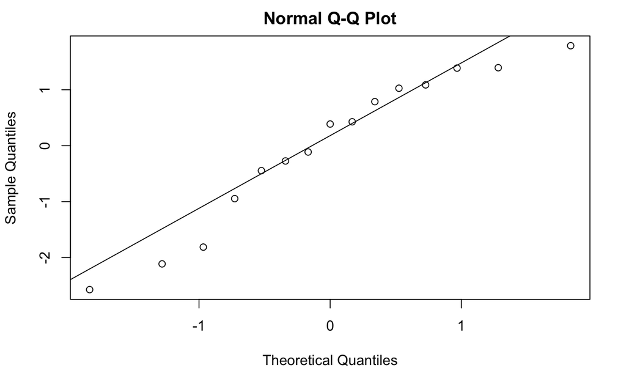

```r
qqnorm(residuals(aovsearch))
qqline(residuals(aovsearch))
```

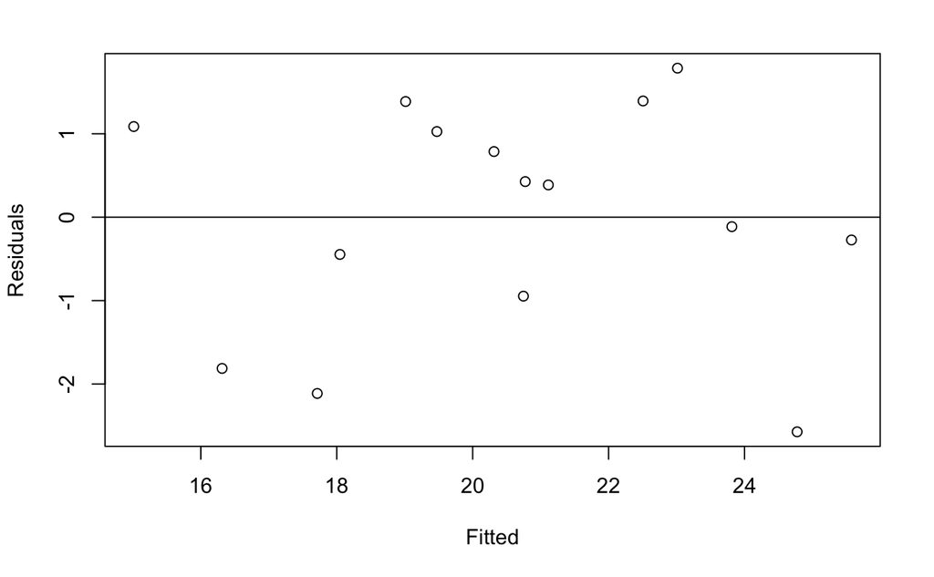

```r
plot(fitted(aovsearch),residuals(aovsearch),xlab="Fitted",ylab="Residuals")
abline(h=0)
```

### 6. Perform the non-parametric Friedman test to test whether there is an effect of interface.

```r
friedman.test(time,interface,skill)
```

```
    Friedman rank sum test

data:  time, interface and skill
Friedman chi-squared = 6.4, df = 2, p-value = 0.04076
```

### 7. Test the null hypothesis that the search time is the same for all interfaces by a one-way analysis of variance test, ignoring the variable skill. Is it right/wrong or useful/not useful to perform this test on this dataset? What assumption on the way the data were obtained is necessary for this test to be valid, and was this assumption met?

```r
search_noskill=search[,-c(2)]
search_noskill$interface=as.factor(search_noskill$interface)
aovsearch_noskill=lm(time~interface,data=search_noskill)
anova(aovsearch_noskill)
```

```
Analysis of Variance Table

Response: time
          Df  Sum Sq Mean Sq F value  Pr(>F)
interface  2  50.465  25.233  2.8605 0.09642 .
Residuals 12 105.852   8.821
---
Signif. codes:  0 ‘***’ 0.001 ‘**’ 0.01 ‘*’ 0.05 ‘.’ 0.1 ‘ ’ 1
```

## EXERCISE 3

```r
cream = read.table("cream.txt", header=TRUE, quote="\"")
```

The file cream.txt contains data on an experiment to produce sour cream. Yogurt was placed in sweet cream, and yogurt bacteria were allowed to develop. Interest was in their number. Bacteria produce lactic acid, and as a surrogate for their number, the acidity of the cream was measured. Interest was in the effect of the type of yogurt used as a starter. The mixtures of yogurt and sweet cream were kept at constant temperature in a yogurt maker, in which five different positions could be used. The experiment was carried out with five batches of sweet cream, which were meant to have the same composition. With each batch each of five types of starter was used, with the yogurt placed in one of the five positions. The combinations of levels of three factors formed a three-dimensional latin square. The data are obtained in the file cream.txt. ###1. Analyse the data in a three-way experiment without interactions: use the model formula acidity∼starter+batch+position. (Beware to include the explanatory variables as factors in the analysis.) Formulate the conclusions.

```r
attach(cream)
cream$batch=as.factor(cream$batch)
cream$position=as.factor(cream$position)
cream$starter=as.factor(cream$starter)
aovcream=lm(acidity~starter+batch+position,data=cream)
anova(aovcream)
```

```
Analysis of Variance Table

Response: acidity
          Df Sum Sq Mean Sq F value    Pr(>F)
starter    4 44.136 11.0340 20.2080 2.904e-05 ***
batch      4 18.778  4.6944  8.5975  0.001632 **
position   4  2.348  0.5870  1.0750  0.411191
Residuals 12  6.552  0.5460
---
Signif. codes:  0 ‘***’ 0.001 ‘**’ 0.01 ‘*’ 0.05 ‘.’ 0.1 ‘ ’ 1
```

### 2. Produce a table of p-values for testing all hypotheses H0 : αi = αi 0 on equality of differences of the main effects for starter simultaneously (i, i0 ∈ {1, 2, . . . , 5}). Which starters lead to significantly different acidity? Interpret.

```r
summary(aovcream)
```

```
Call:
lm(formula = acidity ~ starter + batch + position, data = cream)

Residuals:
    Min      1Q  Median      3Q     Max
-1.2836 -0.2336  0.0384  0.3584  1.0204

Coefficients:
            Estimate Std. Error t value Pr(>|t|)
(Intercept)   8.6616     0.5329  16.255 1.55e-09 ***
starter2     -0.1500     0.4673  -0.321   0.7538
starter3     -0.9800     0.4673  -2.097   0.0579 .
starter4      2.8100     0.4673   6.013 6.10e-05 ***
starter5     -0.4840     0.4673  -1.036   0.3208
batch2       -1.3480     0.4673  -2.884   0.0137 *
batch3        0.2760     0.4673   0.591   0.5658
batch4        1.3680     0.4673   2.927   0.0127 *
batch5        0.2000     0.4673   0.428   0.6763
position2    -0.6180     0.4673  -1.322   0.2107
position3    -0.0380     0.4673  -0.081   0.9365
position4    -0.7640     0.4673  -1.635   0.1280
position5    -0.2640     0.4673  -0.565   0.5825
---
Signif. codes:  0 ‘***’ 0.001 ‘**’ 0.01 ‘*’ 0.05 ‘.’ 0.1 ‘ ’ 1

Residual standard error: 0.7389 on 12 degrees of freedom
Multiple R-squared:  0.9088,    Adjusted R-squared:  0.8175
F-statistic:  9.96 on 12 and 12 DF,  p-value: 0.0001777
```

### 3. A p-value for the test H0 : α2 = α1 is also in the output of summary in 2). What is it? Is it coincidence that it is smaller than the simultaneous p-value?

```r
# install.packages(multcomp)
library(multcomp)
multcream=glht(aovcream,linfct=mcp(starter="Tukey"))
summary(multcream)
```

```
     Simultaneous Tests for General Linear Hypotheses

Multiple Comparisons of Means: Tukey Contrasts


Fit: lm(formula = acidity ~ starter + batch + position, data = cream)

Linear Hypotheses:
           Estimate Std. Error t value Pr(>|t|)
2 - 1 == 0  -0.1500     0.4673  -0.321 0.997367
3 - 1 == 0  -0.9800     0.4673  -2.097 0.282054
4 - 1 == 0   2.8100     0.4673   6.013 0.000501 ***
5 - 1 == 0  -0.4840     0.4673  -1.036 0.834310
3 - 2 == 0  -0.8300     0.4673  -1.776 0.428889
4 - 2 == 0   2.9600     0.4673   6.334 0.000296 ***
5 - 2 == 0  -0.3340     0.4673  -0.715 0.949091
4 - 3 == 0   3.7900     0.4673   8.110  < 1e-04 ***
5 - 3 == 0   0.4960     0.4673   1.061 0.822247
5 - 4 == 0  -3.2940     0.4673  -7.048 0.000119 ***
---
Signif. codes:  0 ‘***’ 0.001 ‘**’ 0.01 ‘*’ 0.05 ‘.’ 0.1 ‘ ’ 1
(Adjusted p values reported -- single-step method)
```

### 4. Produce a table of confidence intervals for testing all differences αi−αi 0 of the main effects for starter with simultaneous confidence level 95% (i, i0 ∈ {1, 2, . . . , 5}). Which intervals do not contain the number 0? Comment.

```r
summary(aovcream)
```

```
Call:
lm(formula = acidity ~ starter + batch + position, data = cream)

Residuals:
    Min      1Q  Median      3Q     Max
-1.2836 -0.2336  0.0384  0.3584  1.0204

Coefficients:
            Estimate Std. Error t value Pr(>|t|)
(Intercept)   8.6616     0.5329  16.255 1.55e-09 ***
starter2     -0.1500     0.4673  -0.321   0.7538
starter3     -0.9800     0.4673  -2.097   0.0579 .
starter4      2.8100     0.4673   6.013 6.10e-05 ***
starter5     -0.4840     0.4673  -1.036   0.3208
batch2       -1.3480     0.4673  -2.884   0.0137 *
batch3        0.2760     0.4673   0.591   0.5658
batch4        1.3680     0.4673   2.927   0.0127 *
batch5        0.2000     0.4673   0.428   0.6763
position2    -0.6180     0.4673  -1.322   0.2107
position3    -0.0380     0.4673  -0.081   0.9365
position4    -0.7640     0.4673  -1.635   0.1280
position5    -0.2640     0.4673  -0.565   0.5825
---
Signif. codes:  0 ‘***’ 0.001 ‘**’ 0.01 ‘*’ 0.05 ‘.’ 0.1 ‘ ’ 1

Residual standard error: 0.7389 on 12 degrees of freedom
Multiple R-squared:  0.9088,    Adjusted R-squared:  0.8175
F-statistic:  9.96 on 12 and 12 DF,  p-value: 0.0001777
```

```r
summary(multcream)
```

```
     Simultaneous Tests for General Linear Hypotheses

Multiple Comparisons of Means: Tukey Contrasts


Fit: lm(formula = acidity ~ starter + batch + position, data = cream)

Linear Hypotheses:
           Estimate Std. Error t value Pr(>|t|)
2 - 1 == 0  -0.1500     0.4673  -0.321 0.997367
3 - 1 == 0  -0.9800     0.4673  -2.097 0.282023
4 - 1 == 0   2.8100     0.4673   6.013 0.000436 ***
5 - 1 == 0  -0.4840     0.4673  -1.036 0.834318
3 - 2 == 0  -0.8300     0.4673  -1.776 0.428921
4 - 2 == 0   2.9600     0.4673   6.334 0.000294 ***
5 - 2 == 0  -0.3340     0.4673  -0.715 0.949089
4 - 3 == 0   3.7900     0.4673   8.110  < 1e-04 ***
5 - 3 == 0   0.4960     0.4673   1.061 0.822234
5 - 4 == 0  -3.2940     0.4673  -7.048 0.000104 ***
---
Signif. codes:  0 ‘***’ 0.001 ‘**’ 0.01 ‘*’ 0.05 ‘.’ 0.1 ‘ ’ 1
(Adjusted p values reported -- single-step method)
```

```r
confint(multcream)
```

```
     Simultaneous Confidence Intervals

Multiple Comparisons of Means: Tukey Contrasts


Fit: lm(formula = acidity ~ starter + batch + position, data = cream)

Quantile = 3.1869
95% family-wise confidence level


Linear Hypotheses:
           Estimate lwr     upr
2 - 1 == 0 -0.1500  -1.6394  1.3394
3 - 1 == 0 -0.9800  -2.4694  0.5094
4 - 1 == 0  2.8100   1.3206  4.2994
5 - 1 == 0 -0.4840  -1.9734  1.0054
3 - 2 == 0 -0.8300  -2.3194  0.6594
4 - 2 == 0  2.9600   1.4706  4.4494
5 - 2 == 0 -0.3340  -1.8234  1.1554
4 - 3 == 0  3.7900   2.3006  5.2794
5 - 3 == 0  0.4960  -0.9934  1.9854
5 - 4 == 0 -3.2940  -4.7834 -1.8046
```

## EXERCISE 4

```r
cow = read.table("cow.txt", header=TRUE, quote="\"")
```

In a study on the effect of feedingstuffs on lactation a sample of nine cows were fed with two types of food, and their milk production was measured. All cows were fed both types of food, during two periods, with a neutral period in-between to try and wash out carry-over effects. The order of the types of food was randomized over the cows. The observed data can be found in the file cow.txt, where A and B refer to the types of feedingstuffs.

### 1. Test whether the type of feedingstuffs influences milk production using an ordinary “fixed effects” model, fitted with lm.

### 2. Estimate the difference in milk production.

### 3. Repeat 1. and 2. by performing a mixed effects analysis, modelling the cow effect as a random effect (use the function lmer). Compare your results to the results found by using a fixed effects model.

### 4. Study the commands: attach(cow)

### t.test(milk[treatment==“A”],milk[treatment==“B”],paired=TRUE)

### Does this produce a valid test for a difference in milk production? Is its

### conclusion compatible with the one obtained in 1.? Why?

```r
attach(cow)
t.test(milk[treatment=="A"],milk[treatment=="B"],paired=TRUE)
```

```
    Paired t-test

data:  milk[treatment == "A"] and milk[treatment == "B"]
t = 0.22437, df = 8, p-value = 0.8281
alternative hypothesis: true difference in means is not equal to 0
95 percent confidence interval:
 -2.267910  2.756799
sample estimates:
mean of the differences
              0.2444444
```

# Experimental Design and Data Analysis: Assignment 5

This assignment consists of 3 exercises. Throughout this assignment tests should be performed using a level of 0.05.

## EXERCISE 1

```r
nauseatable = read.table("nauseatable.txt", header=TRUE, quote="\"")
```

The file nauseatable contains data about post-operative nausea after medication against nausea. Two different medicines were administered to patients that complained about post-operative nausea. One of the medicines, Pentobarbital, was administered in two different doses. ###1. Set up a data.frame in R existing of two columns and 304 rows. One column should contain an indicator whether or not the patient in that row suffered from nausea, and the other column should indicate the medicin. (Use nausea.frame=data.frame(nausea,medicin) where nausea is a vector 0’s and 1’s and medicin is the vector containing the medicin labels for each patient. Make sure these columns match correctly.)

### 2. Study the outcome of xtabs(∼medicin+naus).

### 3. Perform a permutation test in order to test whether the different medicins work equally well against nausea. Permute the medicin labels for this purpose. Use as test statistic the chisquare test statistic for contingency tables, which can be extracted from the output of chisq.test: chisq.test(xtabs(∼medicin+nausea))[[1]].

### 4. Compare the p-value found by the permutation test with the p-value found from the chisquare test for contingency tables. Explain the difference/equality of the two p-values.

# EXERCISE 2

```r
airpollution = read.table("airpollution.txt", header=TRUE, quote="\"")
```

This exercise concerns the data in the file airpollution. Investigate which explanatory variables need to be included into a linear regression model with oxidant as the response variable. Do this as follows.

### 1. Make scatter plots of the candidate explanatory variables against each other and against the response variable (see the R-function pairs()). Interpret the plots. Do you judge a linear model to be useful here?

### 2. Determine for each of the explanatory variables the simple linear regression model. Choose the best among these models, and stepwise extend this model by adding one explanatory variable per step on the basis of the determination coefficient. Use a test to investigate whether the extensions are useful. Determine in this way an appropriate linear regression model for these data.

### 3. Estimate the parameters in the full linear regression model with all explanatory variables in it. Now stepwise decrease this full model with the aid of tests of the form H0 : βi = 0. Determine in this way an appropriate linear regression model for the data.

### 4. Present the estimates of the parameters of the final model of your choice.

### 5. Investigate the normality of the residuals of the chosen model. Do you think, in view of all results, that the chosen linear model is appropriate?

## EXERCISE 3

```r
expensescrime = read.table("expensescrime.txt", header=TRUE, quote="\"")
attach(expensescrime)
```

The data in expensescrime were obtained to determine factors related to state expenditures on criminal activities (courts, police, etc.) The variables are: state (indicating the state in the USA), expend (state expenditures on criminal activities in $1000), bad (number of persons under criminal supervision), crime (crime rate per 100000), lawyers (number of lawyers in the state), employ (number of persons employed in the state) and pop (population of the state in 1000). Perform a regression analysis using expend as response variable and bad, crime, lawyers, employ and pop as independent variables. Present your final model. Your analysis should at least include: ###a. investigation of potential or influence points

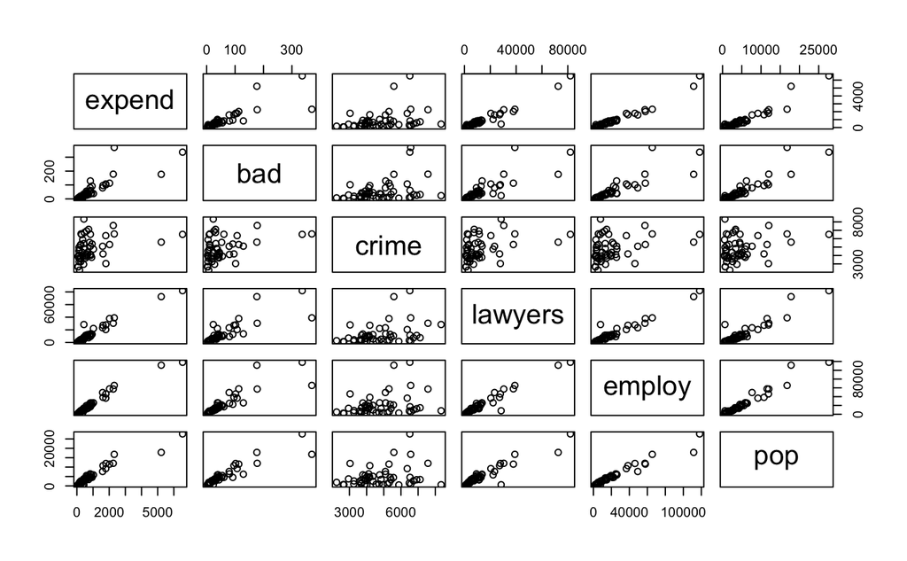

```r
pairs(expensescrime[2:7])
```

according to the pairs graph expend and almost every other variable has some outliers so we use cooks distance to see this influence poits more clearly

```r
fit0 = lm(expend ~ bad + crime + lawyers +employ+pop)
round(cooks.distance(fit0),2)
```

```
   1    2    3    4    5    6    7    8    9   10   11   12   13   14   15   16   17   18   19   20   21   22   23   24   25
0.02 0.00 0.00 0.01 4.91 0.00 0.00 3.51 0.00 0.02 0.00 0.00 0.00 0.00 0.14 0.01 0.00 0.00 0.00 0.03 0.01 0.00 0.01 0.00 0.00
  26   27   28   29   30   31   32   33   34   35   36   37   38   39   40   41   42   43   44   45   46   47   48   49   50
0.00 0.00 0.00 0.01 0.00 0.00 0.14 0.00 0.00 1.09 0.07 0.00 0.00 0.11 0.00 0.00 0.01 0.00 2.70 0.00 0.00 0.00 0.00 0.00 0.00
  51
0.00
```

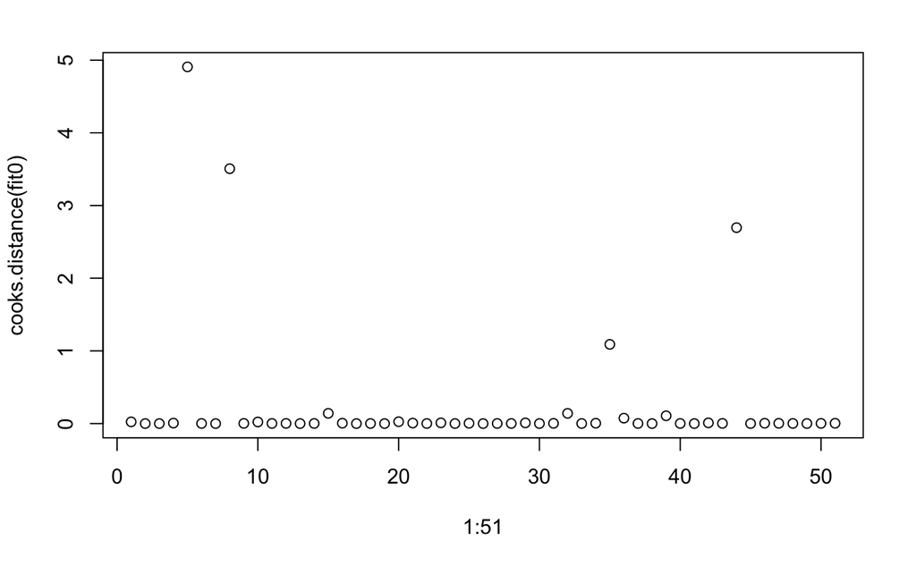

```r
plot(1:51,cooks.distance(fit0))
```

we see that 5, 8, 35 and 44 are close or higher than 1 and therfore influencal

using car library

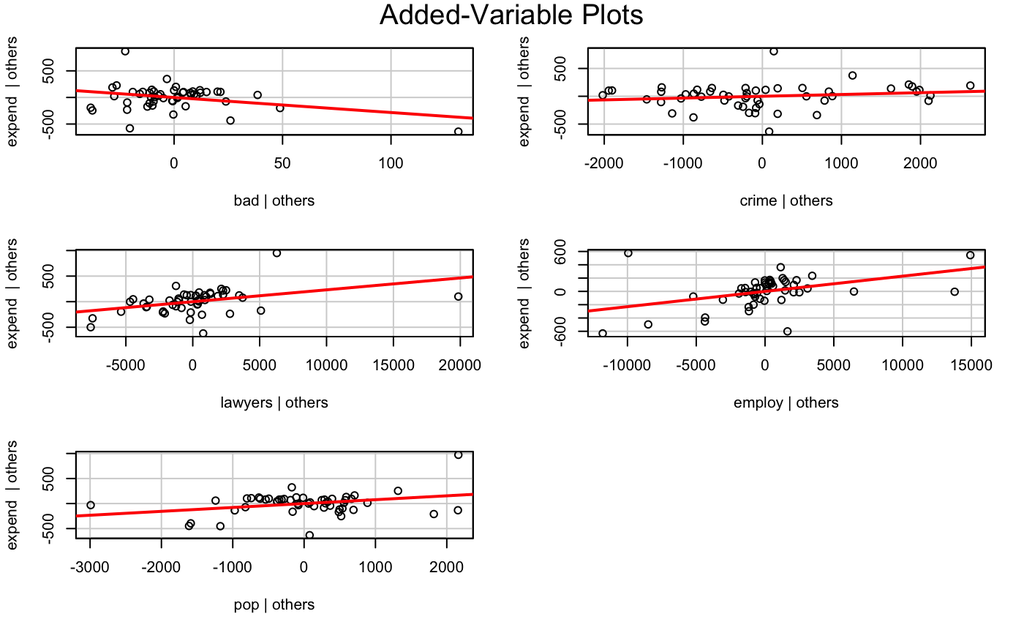

```r
library(car)
avPlots(fit0)
```

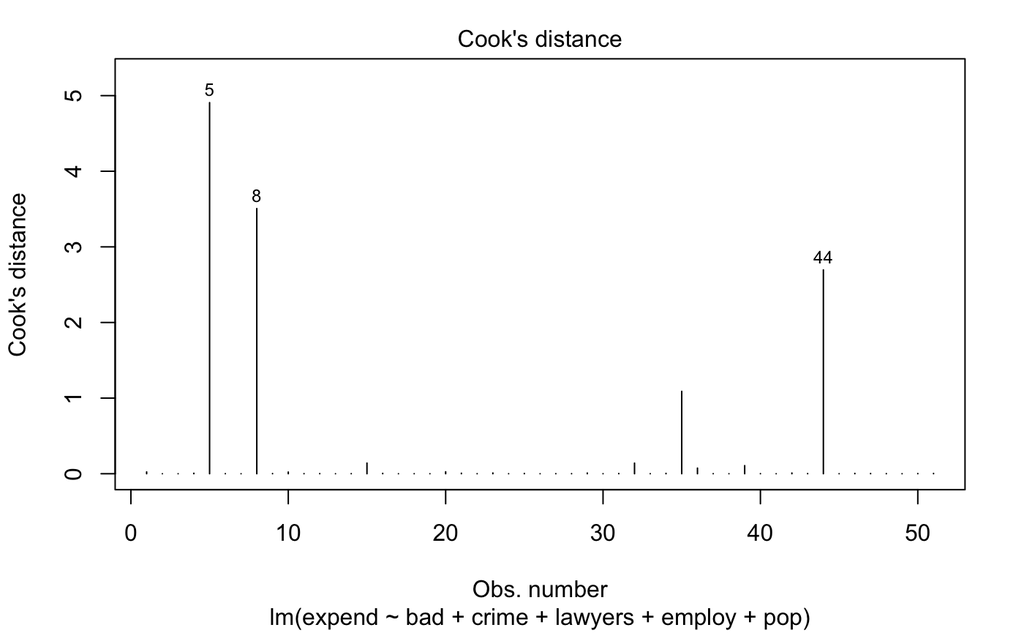

```r
cutoff <- 4/((nrow(expensescrime)-length(fit0$coefficients)-2))
plot(fit0, which=4, cook.levels=cutoff)
```

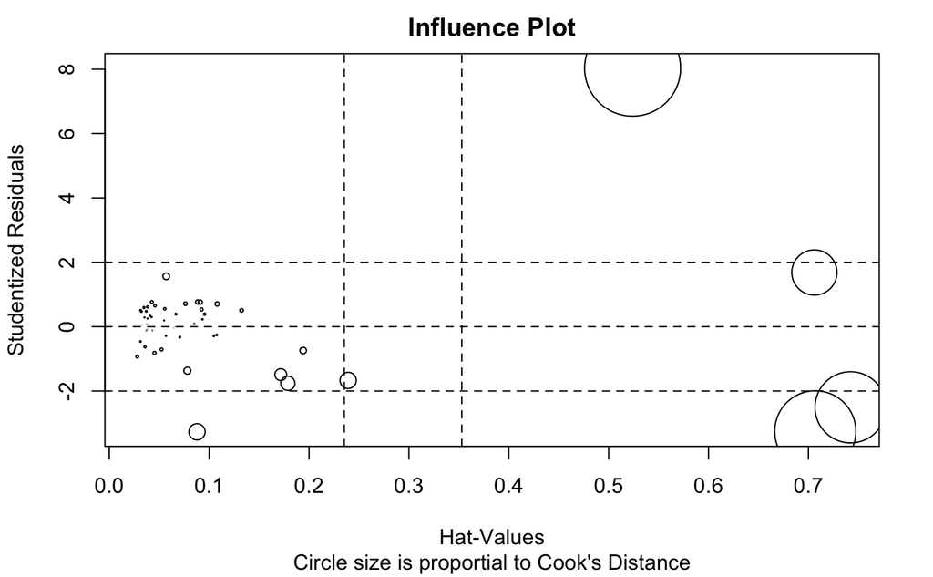

```r
influencePlot(fit0, id.method="identify", main="Influence Plot", sub="Circle size is proportial to Cook's Distance" )
```

big circles show the influencal points that are close to 1 from 0.5 to 0.7 this confirms the previous findings

### b. investigation of problems due to collinearity

we compare xi and xj and if they have large variance and large confidence interval then they are colinear for multiple variables we can use laso but not in this course scatter plot X1 against all other x calculate linear corelation for all combinations check if they are far from 0 using cor fucntion we see pairwise colinearity and the ones near 1 are co linear

```r
round(cor(expensescrime[,3:7]),2)
```

```
         bad crime lawyers employ  pop
bad     1.00  0.37    0.83   0.87 0.92
crime   0.37  1.00    0.38   0.31 0.28
lawyers 0.83  0.38    1.00   0.97 0.93
employ  0.87  0.31    0.97   1.00 0.97
pop     0.92  0.28    0.93   0.97 1.00
```

results show strong corelation between pop and bad as well as pop and employ to clarfy we will also use scatter plots to check it visually

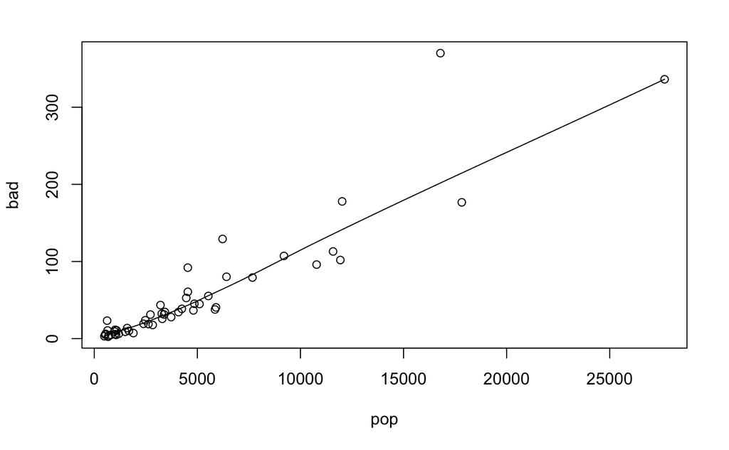

```r
scatter.smooth(pop,bad)
```

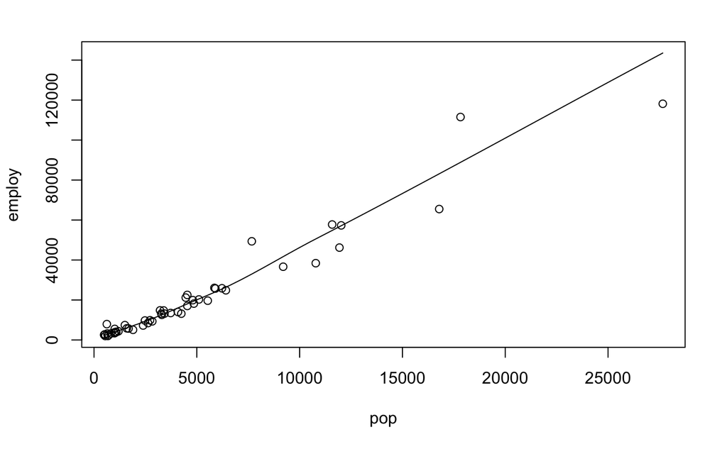

```r
scatter.smooth(pop,employ)
```

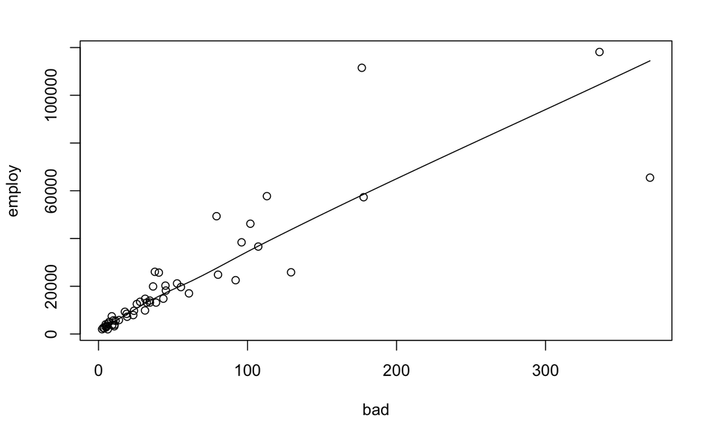

```r
scatter.smooth(bad,employ)
```

scatter plot confirms our observation about co linear variables

### c. investigation of residuals.

```r
fit1 = lm(expend ~ bad + crime + lawyers +employ+pop)
summary(fit1)
```

```
Call:
lm(formula = expend ~ bad + crime + lawyers + employ + pop)

Residuals:
    Min      1Q  Median      3Q     Max
-638.41  -87.42   22.15  114.96  804.98

Coefficients:
              Estimate Std. Error t value Pr(>|t|)
(Intercept) -2.991e+02  1.401e+02  -2.136  0.03817 *
bad         -2.832e+00  1.240e+00  -2.283  0.02719 *
crime        3.241e-02  2.813e-02   1.152  0.25534
lawyers      2.324e-02  8.044e-03   2.890  0.00592 **
employ       2.297e-02  7.462e-03   3.078  0.00354 **
pop          7.787e-02  3.515e-02   2.215  0.03184 *
---
Signif. codes:  0 ‘***’ 0.001 ‘**’ 0.01 ‘*’ 0.05 ‘.’ 0.1 ‘ ’ 1

Residual standard error: 225.6 on 45 degrees of freedom
Multiple R-squared:  0.9675,    Adjusted R-squared:  0.9639
F-statistic: 268.2 on 5 and 45 DF,  p-value: < 2.2e-16
```

we notice crime is not significant so we step down

```r
fit2 = lm(expend ~ bad  + lawyers +employ+pop)
summary(fit2)
```

```
Call:
lm(formula = expend ~ bad + lawyers + employ + pop)

Residuals:
    Min      1Q  Median      3Q     Max
-635.62  -80.18   18.77  114.54  809.66

Coefficients:
              Estimate Std. Error t value Pr(>|t|)
(Intercept) -1.464e+02  4.541e+01  -3.224  0.00232 **
bad         -2.241e+00  1.133e+00  -1.977  0.05402 .
lawyers      2.646e-02  7.571e-03   3.495  0.00106 **
employ       2.283e-02  7.487e-03   3.049  0.00380 **
pop          6.368e-02  3.304e-02   1.927  0.06012 .
---
Signif. codes:  0 ‘***’ 0.001 ‘**’ 0.01 ‘*’ 0.05 ‘.’ 0.1 ‘ ’ 1

Residual standard error: 226.4 on 46 degrees of freedom
Multiple R-squared:  0.9666,    Adjusted R-squared:  0.9637
F-statistic: 332.5 on 4 and 46 DF,  p-value: < 2.2e-16
```

we notice =R squared reduces slightly but no signifucant reduction since we know pop and bad are co linear we remove one

```r
fit3 = lm(expend ~ bad + crime + lawyers +employ)
summary(fit3)
```

```
Call:
lm(formula = expend ~ bad + crime + lawyers + employ)

Residuals:
    Min      1Q  Median      3Q     Max
-632.38  -89.76   37.16   94.65  973.34

Coefficients:
              Estimate Std. Error t value Pr(>|t|)
(Intercept) -1.578e+02  1.299e+02  -1.215  0.23043
bad         -9.555e-01  9.438e-01  -1.012  0.31662
crime        1.059e-02  2.745e-02   0.386  0.70152
lawyers      2.525e-02  8.326e-03   3.033  0.00398 **
employ       3.305e-02  6.159e-03   5.367 2.54e-06 ***
---
Signif. codes:  0 ‘***’ 0.001 ‘**’ 0.01 ‘*’ 0.05 ‘.’ 0.1 ‘ ’ 1

Residual standard error: 235 on 46 degrees of freedom
Multiple R-squared:  0.964, Adjusted R-squared:  0.9609
F-statistic: 307.9 on 4 and 46 DF,  p-value: < 2.2e-16
```

bad and crime lost their significance so we step down by removing them

```r
fit4 = lm(expend ~ lawyers +employ)
summary(fit4)
```

```
Call:
lm(formula = expend ~ lawyers + employ)

Residuals:
    Min      1Q  Median      3Q     Max
-599.47  -94.43   36.01   91.98  936.55

Coefficients:
              Estimate Std. Error t value Pr(>|t|)
(Intercept) -1.107e+02  4.257e+01  -2.600  0.01236 *
lawyers      2.686e-02  7.757e-03   3.463  0.00113 **
employ       2.971e-02  5.114e-03   5.810 4.89e-07 ***
---
Signif. codes:  0 ‘***’ 0.001 ‘**’ 0.01 ‘*’ 0.05 ‘.’ 0.1 ‘ ’ 1

Residual standard error: 232.6 on 48 degrees of freedom
Multiple R-squared:  0.9632,    Adjusted R-squared:  0.9616
F-statistic: 627.7 on 2 and 48 DF,  p-value: < 2.2e-16
```

now the R squered is still high and close to previous models while we only have lawyers and employ as our most significant values

we are refitting the data using step up this time starting with the first variable bad

```r
fit1 = lm(expend ~ bad)
summary(fit1)
```

```
Call:
lm(formula = expend ~ bad)

Residuals:
     Min       1Q   Median       3Q      Max
-2744.80  -129.97   -69.01    91.78  2738.99

Coefficients:
            Estimate Std. Error t value Pr(>|t|)
(Intercept)  126.721    114.865   1.103    0.275
bad           13.324      1.257  10.601  2.8e-14 ***
---
Signif. codes:  0 ‘***’ 0.001 ‘**’ 0.01 ‘*’ 0.05 ‘.’ 0.1 ‘ ’ 1

Residual standard error: 661 on 49 degrees of freedom
Multiple R-squared:  0.6964,    Adjusted R-squared:  0.6902
F-statistic: 112.4 on 1 and 49 DF,  p-value: 2.796e-14
```

next we add crime

```r
fit2 = lm(expend ~ bad +crime)
summary(fit2)
```

```
Call:
lm(formula = expend ~ bad + crime)

Residuals:
     Min       1Q   Median       3Q      Max
-2734.97  -132.05   -64.19    58.13  2740.45

Coefficients:
             Estimate Std. Error t value Pr(>|t|)
(Intercept)  24.27802  345.45372   0.070    0.944
bad          13.16311    1.36715   9.628 8.63e-13 ***
crime         0.02314    0.07352   0.315    0.754
---
Signif. codes:  0 ‘***’ 0.001 ‘**’ 0.01 ‘*’ 0.05 ‘.’ 0.1 ‘ ’ 1

Residual standard error: 667.2 on 48 degrees of freedom
Multiple R-squared:  0.697, Adjusted R-squared:  0.6844
F-statistic: 55.21 on 2 and 48 DF,  p-value: 3.583e-13
```

the R squered increases very slightly but crime has no significance so we dont concider it

```r
fit3 = lm(expend ~ bad + lawyers )
summary(fit3)
```

```
Call:
lm(formula = expend ~ bad + lawyers)

Residuals:
     Min       1Q   Median       3Q      Max
-1369.04   -30.80    43.51    82.04   796.37

Coefficients:
              Estimate Std. Error t value Pr(>|t|)
(Intercept) -67.588144  53.421572  -1.265    0.212
bad           1.509556   1.016933   1.484    0.144
lawyers       0.064666   0.004631  13.965   <2e-16 ***
---
Signif. codes:  0 ‘***’ 0.001 ‘**’ 0.01 ‘*’ 0.05 ‘.’ 0.1 ‘ ’ 1

Residual standard error: 296.8 on 48 degrees of freedom
Multiple R-squared:   0.94, Adjusted R-squared:  0.9375
F-statistic: 376.2 on 2 and 48 DF,  p-value: < 2.2e-16
```

with R squered at 0.94 we have a huge increase but the model shows that bad lost its significance so we remove it and we keep lawyer and add the next one

```r
fit3 = lm(expend ~ lawyers + employ )
summary(fit3)
```

```
Call:
lm(formula = expend ~ lawyers + employ)

Residuals:
    Min      1Q  Median      3Q     Max
-599.47  -94.43   36.01   91.98  936.55

Coefficients:
              Estimate Std. Error t value Pr(>|t|)
(Intercept) -1.107e+02  4.257e+01  -2.600  0.01236 *
lawyers      2.686e-02  7.757e-03   3.463  0.00113 **
employ       2.971e-02  5.114e-03   5.810 4.89e-07 ***
---
Signif. codes:  0 ‘***’ 0.001 ‘**’ 0.01 ‘*’ 0.05 ‘.’ 0.1 ‘ ’ 1

Residual standard error: 232.6 on 48 degrees of freedom
Multiple R-squared:  0.9632,    Adjusted R-squared:  0.9616
F-statistic: 627.7 on 2 and 48 DF,  p-value: < 2.2e-16
```

we see another increase in R squered and both lawyer and emply are significant so we add our final attribute

```r
fit4 = lm(expend ~ lawyers + employ +pop )
summary(fit4)
```

```
Call:
lm(formula = expend ~ lawyers + employ + pop)

Residuals:
    Min      1Q  Median      3Q     Max
-633.76  -91.82   34.49  100.23  866.93

Coefficients:
              Estimate Std. Error t value Pr(>|t|)
(Intercept) -1.233e+02  4.522e+01  -2.728  0.00894 **
lawyers      2.723e-02  7.791e-03   3.494  0.00105 **
employ       2.490e-02  7.640e-03   3.258  0.00209 **
pop          2.246e-02  2.642e-02   0.850  0.39939
---
Signif. codes:  0 ‘***’ 0.001 ‘**’ 0.01 ‘*’ 0.05 ‘.’ 0.1 ‘ ’ 1

Residual standard error: 233.3 on 47 degrees of freedom
Multiple R-squared:  0.9637,    Adjusted R-squared:  0.9614
F-statistic: 416.3 on 3 and 47 DF,  p-value: < 2.2e-16
```

There is a slight increase in R squered but pop has no siginificance

You may use all techniques mentioned on the lecture slides. State clearly all the choices you make during the regression analysis, including arguments for all your choices. (Note that there are several strategies possible!)

the best model for step up is fit3 = lm(expend ~ lawyers + employ ) with Multiple R-squared: 0.9632 this compares to fit4 = lm(expend ~ lawyers +employ) for step down with Multiple R-squared: 0.9632 both methods resulted in the same model

finaly we plot the residuals to see if they are curved

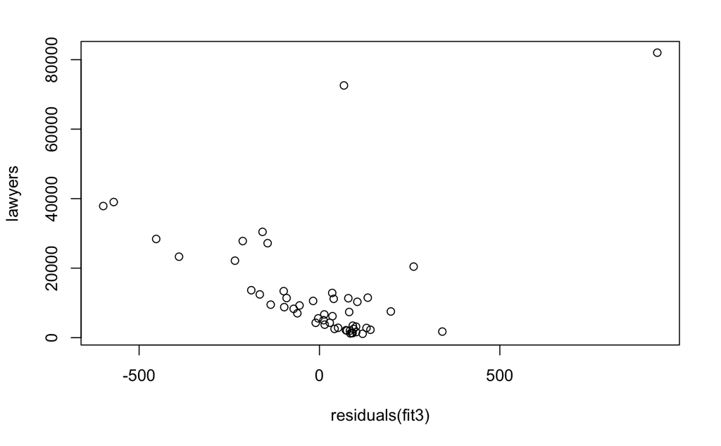

```r
plot(residuals(fit3),lawyers)
```

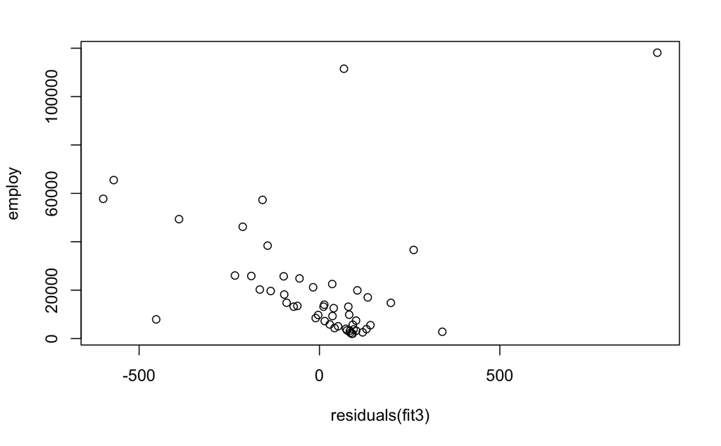

```r
plot(residuals(fit3),employ)
```

finalyl checking the model with y and the fitted y

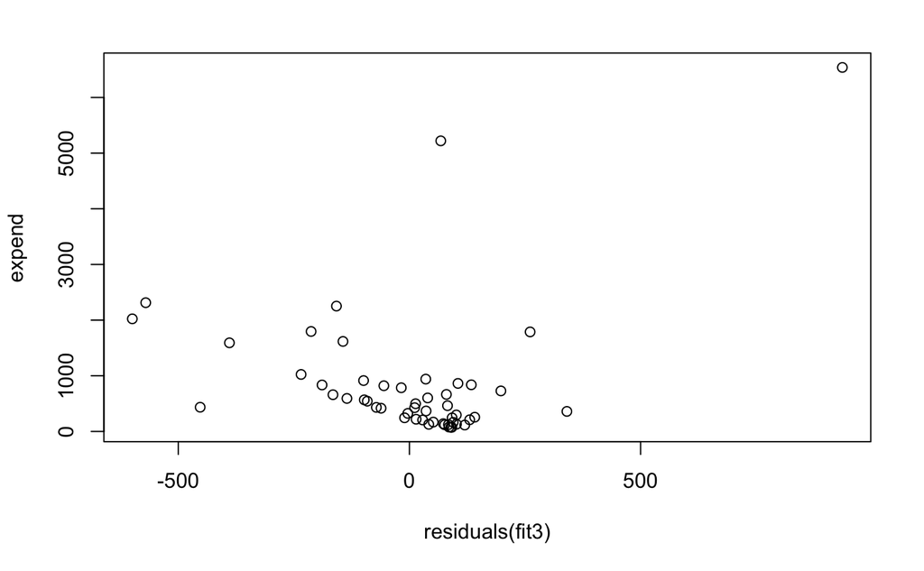

```r
plot(residuals(fit3),expend)
```

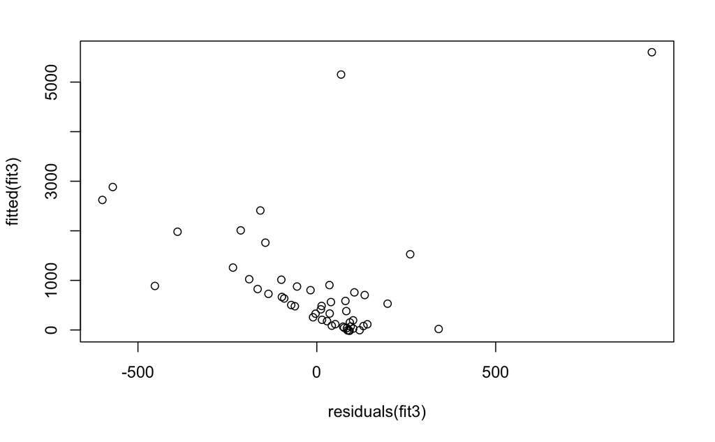

```r
plot(residuals(fit3),fitted(fit3))
```

both graphs have the same spread